# Modules

## Modules

- modules are Python .py files
- you can make your own modules
- standard modules in [Python Standard Library](https://docs.python.org/3/library/)
- Python Standard Library is part of every Python

## Is module ready to go

- simply run import mudule_name
- if there is no feedback, module is ready to be used

```python
import math
```

- if module is not ready to be used, you will get an error

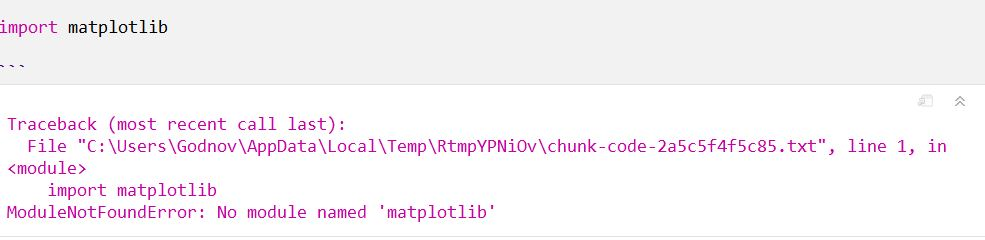

## Installing module

- cmd
- pip install matplotlib
- conda install matplotlib

## Importing module

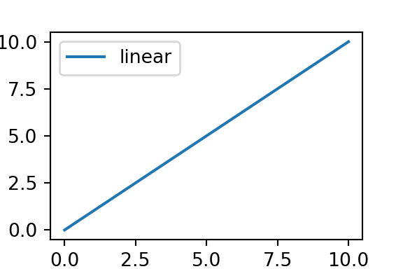

```python
# Import the necessary packages and modules
import matplotlib.pyplot as plt
import numpy as np
import os
os.environ['QT_QPA_PLATFORM_PLUGIN_PATH'] = 'C:/Users/Godnov/Anaconda3/Library/plugins/platforms'
# Prepare the data
x = np.linspace(0, 10, 100)
# Plot the data
plt.plot(x, x, label='linear')
# Add a legend
plt.legend()
# Show the plot
plt.show()
```

## from … import and aliasing modules

- items from a module within your programâ€™s namespace
- you can refer to the functions by name rather than through dot notation
- *from matplotlib import pyplot*
- *import [module] as [another_name]*
- *import matplotlib.pyplot as plt*
- *from matplotlib import pyplot as plt*

## Help on modules

- help: creates help in interpreter
- using help(): help(random)
- pydoc can invoke help outside interpreter
- which modules are installed: help(modules)

## Excercise

- create 5 random integer numbers from 1-10
- use random module
- use help to find the right function
- import only necessary function from module and give it alias *r*

```
## 4
## 3
## 9
## 8
## 8
```